# T-tests with data

Peace Okoko

12/17/2020

Load packages

```r
library(tidyverse)
```

```r
# tidyverse loads these that we'll use today:
library(readr)
library(dplyr)
library(ggplot2)
library(tidyr)
```

#Data Creation Data was created based on the means of participants in each of the groups. We chose three categories to look at in the healthcare section. We wanted to see whether there was any difference on the parameters used to measure health between a violence only approach and a violence+education approach. We ended up with three groups for questions regarding health. These are:“Knowledge of modern contraceptive”,“Has female adult in community” and “Has female adult that meets regularly in the community”

```r
#Data 1
set.seed(24)
healthy<-tibble(
  group=rep(c("Knowledge of modern contraceptive method without  probing","Has female adult in community","Has female adult meets regularly in community"),each=500),
  intervention<-data.frame(
   #Setting the seed to 14
    V=c(rnorm(n=500,mean=1618.762,sd=3),
        rnorm(n=500,mean=1240.566,sd=2),
        rnorm(n=500,mean=1142.90,sd=5)
        ),
    VE=c(rnorm(n=500,mean=1739.206,sd=3),
         rnorm(n=500,mean=1255.122,sd=2),
         rnorm(n=500,mean=1105.496,sd=5)
         ),
    VEH=c(rnorm(n=500,mean=1703.96,sd=3),
          rnorm(n=500,mean=1346.544,sd=2),
          rnorm(n=500,mean=1178.226,sd=5)
          )
  )
)

healthy
```

```
## # A tibble: 1,500 x 4
##    group                                                         V    VE   VEH
##    <chr>                                                     <dbl> <dbl> <dbl>
##  1 Knowledge of modern contraceptive method without  probing 1617. 1739. 1704.
##  2 Knowledge of modern contraceptive method without  probing 1620. 1740. 1704.
##  3 Knowledge of modern contraceptive method without  probing 1620. 1738. 1705.
##  4 Knowledge of modern contraceptive method without  probing 1617. 1740. 1705.
##  5 Knowledge of modern contraceptive method without  probing 1621. 1736. 1705.
##  6 Knowledge of modern contraceptive method without  probing 1620. 1739. 1706.
##  7 Knowledge of modern contraceptive method without  probing 1620. 1739. 1707.
##  8 Knowledge of modern contraceptive method without  probing 1617. 1740. 1699.
##  9 Knowledge of modern contraceptive method without  probing 1616. 1739. 1706.
## 10 Knowledge of modern contraceptive method without  probing 1619. 1740. 1705.
## # ... with 1,490 more rows
```

#Filtering data In order to analyze the data we have to isolate it into groups.

```r
##Filter the data to just have Knowledge of modern contrace[tive only
healthyKnow<-healthy%>%filter(group=="Knowledge of modern contraceptive method without  probing")
healthyFem<-healthy%>%filter(group=="Has female adult in community")
healthyFemMeet<-healthy%>%filter(group=="Has female adult meets regularly in community")
```

##Display the data to make sure it is only the Know section

```r
healthyKnow
```

```
## # A tibble: 500 x 4
##    group                                                         V    VE   VEH
##    <chr>                                                     <dbl> <dbl> <dbl>
##  1 Knowledge of modern contraceptive method without  probing 1617. 1739. 1704.
##  2 Knowledge of modern contraceptive method without  probing 1620. 1740. 1704.
##  3 Knowledge of modern contraceptive method without  probing 1620. 1738. 1705.
##  4 Knowledge of modern contraceptive method without  probing 1617. 1740. 1705.
##  5 Knowledge of modern contraceptive method without  probing 1621. 1736. 1705.
##  6 Knowledge of modern contraceptive method without  probing 1620. 1739. 1706.
##  7 Knowledge of modern contraceptive method without  probing 1620. 1739. 1707.
##  8 Knowledge of modern contraceptive method without  probing 1617. 1740. 1699.
##  9 Knowledge of modern contraceptive method without  probing 1616. 1739. 1706.
## 10 Knowledge of modern contraceptive method without  probing 1619. 1740. 1705.
## # ... with 490 more rows
```

#Independent t-test Run a t-test to see if there is a difference between the means. If the null hypothesis is correct then there should be a 0 difference between the two means

The first parameter we chose is the knowledge of Modern Contraceptives without probing at the end of the study. Having this knowledge means the girls were able to name contraceptive methods without being asked about a specific one.The knowledge of modern contraceptives is important as it is useful in preventing pregnancy.

```r
##T-Test comparing Violence only group and violence and education group in Knowledge of Modern Contraceptives
t.test(healthyKnow$V,healthyKnow$VE )
```

```
##
##  Welch Two Sample t-test
##
## data:  healthyKnow$V and healthyKnow$VE
## t = -639.42, df = 996.45, p-value < 2.2e-16
## alternative hypothesis: true difference in means is not equal to 0
## 95 percent confidence interval:
##  -121.0413 -120.3006
## sample estimates:
## mean of x mean of y
##  1618.599  1739.270
```

> The t-test results t(996.45)=-639.42,p<.05. There is a difference in the means between girls that had the violence only intervention and those that had the violence and education intervention. Thus, we must reject the null hypothesis because the test is statistically significant.The results are significant meaning those with the education and violence intervention had greater knowledge of contraceptive methods without probing.

T-Test for having an adult female in the community to talk to

```r
##T-Test comparing Violence only group and violence and education group in Has female adult in community
t.test(healthyFem$V,healthyFem$VE )
```

```
##
##  Welch Two Sample t-test
##
## data:  healthyFem$V and healthyFem$VE
## t = -112.89, df = 995.82, p-value < 2.2e-16
## alternative hypothesis: true difference in means is not equal to 0
## 95 percent confidence interval:
##  -14.92797 -14.41785
## sample estimates:
## mean of x mean of y
##  1240.487  1255.160
```

```r
qt(c(0.025,0.975),df=998)
```

```
## [1] -1.962344  1.962344
```

The final parameter we chose on health is how often the girls met with a female adult in the community. This parameter shows consistency and the amount of knowledge on received. One of the things the study wanted to achieve is have the girls regularly meet with an adult to discuss the issues they were going through.

```r
t.test(healthyFemMeet$V,healthyFemMeet$VE)
```

```
##
##  Welch Two Sample t-test
##
## data:  healthyFemMeet$V and healthyFemMeet$VE
## t = 116.43, df = 997.52, p-value < 2.2e-16
## alternative hypothesis: true difference in means is not equal to 0
## 95 percent confidence interval:
##  36.4009 37.6490
## sample estimates:
## mean of x mean of y
##  1142.722  1105.697
```

**REGRESSION TEST (just curious) Is there in correlation between the Violence only group and the violence and education group? For meeting with female adult regularly?

```r
healthyFemMeet<-healthy%>%filter(group=="Has female adult meets regularly in community")
r <- cor(healthyFemMeet$V, healthyFemMeet$VE,
    use="complete.obs")
r
```

```
## [1] 0.09068983
```

**CHI-SQUARED TEST Is there any relationship between the violence only and violence+Education

```r
healthyFemMeet<-healthy%>%filter(group=="Has female adult meets regularly in community")
chisq.test(table(healthyFemMeet$V, healthyFemMeet$VE))
```

```
##
##  Pearson's Chi-squared test
##
## data:  table(healthyFemMeet$V, healthyFemMeet$VE)
## X-squared = 249500, df = 249001, p-value = 0.2396
```

#Graphs Knowledge on contraceptive methods without probing

```r
healthyKnow2 <- healthy%>%filter(group=="Knowledge of modern contraceptive method without  probing") %>%
  pivot_longer(cols=c(V,VE,VEH),names_to="treatment",
  values_to="intervention")%>%group_by(treatment)%>%
  summarize(meanscore = mean(intervention),
            sdscore   = sd(intervention),
            sem       = sdscore/sqrt(n()))
healthyKnow2
```

```
## # A tibble: 3 x 4
##   treatment meanscore sdscore   sem
##   <chr>         <dbl>   <dbl> <dbl>
## 1 V             1619.    3.04 0.136
## 2 VE            1739.    2.92 0.131
## 3 VEH           1704.    2.94 0.131
```

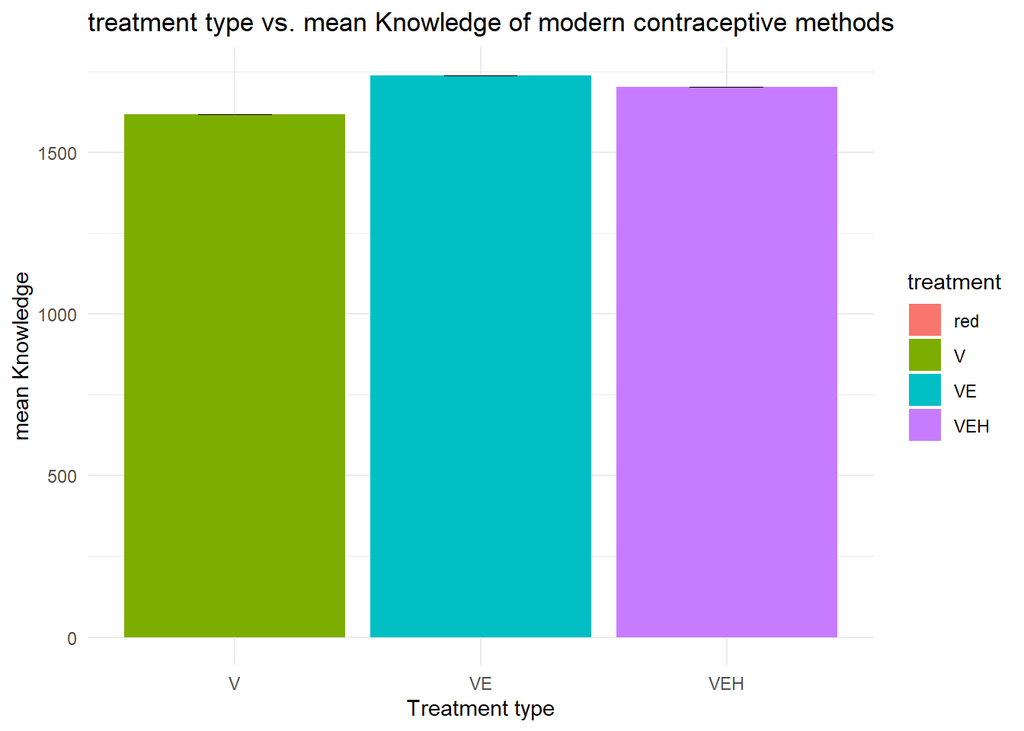

```r
ggplot(healthyKnow2,aes(x=treatment,y=meanscore, fill=treatment))+
  geom_col()+
  theme_minimal()+
  geom_errorbar(aes(ymin=meanscore-sem,ymax=meanscore+sem,fill="red"),
                width=0.3,size=0.02,position = position_dodge(width = .3))+
  labs(x="Treatment type",y="mean Knowledge", title="treatment type vs. mean Knowledge of modern contraceptive methods")
```

>The highest bar for knowledge is the one with the VE treatment.

```r
healthyFem3 <- healthy%>%filter(group=="Has female adult in community")
#%>%pivot_longer(cols = c(VE,V,VEH),names_to = "treatment", values_to = "intervention")%>% group_by(treatment)
healthyFem3
```

```
## # A tibble: 500 x 4
##    group                             V    VE   VEH
##    <chr>                         <dbl> <dbl> <dbl>
##  1 Has female adult in community 1242. 1257. 1347.
##  2 Has female adult in community 1238. 1254. 1343.
##  3 Has female adult in community 1241. 1258. 1346.
##  4 Has female adult in community 1238. 1258. 1349.
##  5 Has female adult in community 1241. 1251. 1347.
##  6 Has female adult in community 1242. 1255. 1347.
##  7 Has female adult in community 1239. 1258. 1351.
##  8 Has female adult in community 1243. 1254. 1351.
##  9 Has female adult in community 1241. 1253. 1342.
## 10 Has female adult in community 1242. 1255. 1349.
## # ... with 490 more rows
```

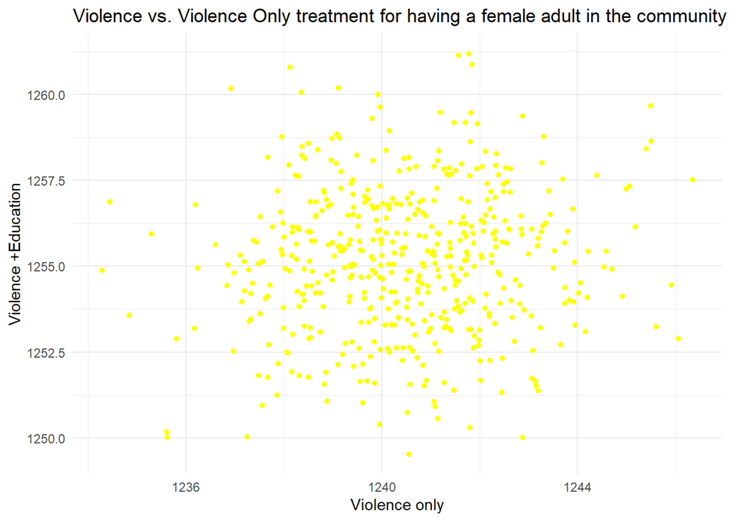

```r
ggplot(healthyFem3,
       aes(x = V, y = VE)) +
  geom_point(color="yellow") +
  geom_abline() +
  theme_minimal()+
  labs(x="Violence only",y="Violence +Education", title="Violence vs. Violence Only treatment for having a female adult in the community")
```

> There is a weak positive correlation between the Violence group and the Violence and Education group.

Last graph using data from regularly meeting with a female adult

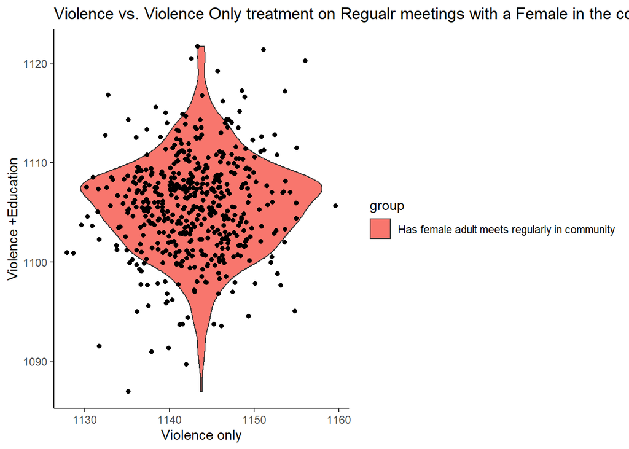

```r
healthyFemMeet<-healthy%>%filter(group=="Has female adult meets regularly in community")
ggplot(healthyFemMeet, aes(x=V,y=VE))+
  geom_violin(aes(fill=group))+
  geom_jitter()+
  theme_classic()+
  labs(x="Violence only",y="Violence +Education", title="Violence vs. Violence Only treatment on Regualr meetings with a Female in the community")
```

>The geom_violin values shows that a lot of the values are concentrated in the middle and then there are few values at each extreme end.